# Table of Contents

##### Imports

```python
# import python packages
import pandas as pd
#%matplotlib inline
import matplotlib.pyplot as plt
import re
from os import path
from PIL import Image
from wordcloud import WordCloud, STOPWORDS
import os
from collections import defaultdict
import itertools
from isodate import parse_duration
import csv

from sklearn import preprocessing
import seaborn as sns
from scipy import stats

import numpy as np
from collections import Counter

import nltk
from nltk.corpus import stopwords
from nltk import FreqDist, word_tokenize
from nltk.stem.porter import PorterStemmer
from nltk.stem import WordNetLemmatizer
from nltk.corpus import stopwords
from textblob import TextBlob

# Vader sentiment
from nltk.sentiment.vader import SentimentIntensityAnalyzer
from nltk import tokenize

from pattern.en import sentiment

# feature engineering (words to vectors)
from sklearn.feature_extraction.text import TfidfVectorizer

# classification algorithms (or classifiers)
from sklearn.naive_bayes import MultinomialNB
from sklearn.neighbors import KNeighborsClassifier
from sklearn.svm import SVC, LinearSVC

# build a pipeline
from sklearn.pipeline import Pipeline

# model evaluation, validation
from sklearn.metrics import classification_report, f1_score, accuracy_score, confusion_matrix
from sklearn.model_selection import StratifiedKFold, cross_val_score, train_test_split, GridSearchCV
from sklearn import metrics
from sklearn.metrics import roc_curve, auc
from scikitplot import plotters as skplt
import scikitplot as skplt
```

# Business Understanding

The purpose of this project is to try and predict if a particular TV show will be either renewed or canceled. This will be based on data collected and analyzed from IMDb and twitter. In particular, I will try to gauge the shows popularity by:

- looking at the IMDb score and the number of users who voted
- analyzing sentiment of the reviews
- analyzing review scores
- analyzing the shows popularity by it twitter following

If successful, the real world applications of this could be:

- Help networks decide whether or not to renew or cancel a show
- Could help entertainment news agencies better predict a shows renewal\cancellation

The question I would like to answer are:

1. Does a strong twitter following lead to a shows renewal?
2. Can the shows IMDb score help to predict it's cancellation?
3. Is there a correlation to the sentiment from the shows reviews and it being renewed\canceled?

## Sources

The source of the data comes from 3 places, Metacritc, IMDb and Twitter.

The data collected from metacritic includes:

- TV show name
- Renewed\Cancel status
- Network show aired on

The data collected from IMDb includes:

- Title
- IMDb Score
- Number of users voted
- If applicable, the shows ranking within IMDb top 250 TV shows
- Keywords
- Genres
- Content rating
- Country
- Language
- Release Date
- Runtime
- TV Network

The Data Collected from Twitter includes:

- Name
- twitter handle (screenname)
- number of follower

## Data Collection Techniques

The methods for collecting the data was web crawling and the Twitter API The code for data collection was written in python separate from the Juptyer Notebook and can be found in the GIT repository. See below for a detailed explanation:

The data collection was split into three parts:

1. Getting the appropriate IMDb links
2. Getting the appropriate IMDb Data
3. Getting the appropriate Twitter data

The first step was to scrape the metacritic website to get a list of renewed\canceled TV shows. Once completed, I could use the shows name to build an IMDb query url in order to find all the IMDb Links associated with the show name. There were some issues where the search string wasn't quite right and IMDb resulted in incorrect results. These were very few and were not added to the final list. The code for the link collection can be found in the **Get_IMDb_Links** folder.

The second step was to collect the IMDb data for each of the links created from the first step. All the data was collected using Beautiful Soup instead of xpath extraction. The code can be found in the **Get_IMDb_Data** folder.

The last step was to collect the Twitter data. This step turned out to be the most challenging as most of of the shows didn't have an Official Site embeded in its IMDb page. I used the Python package Tweepy to search twitter for users with the query string being the show name. In some cases, I added the network to the query string.

In the case where I did have a link from IMDb to the shows Official Twitter page, I noticed that some of those links were not working. I found out that was due the fact that the tokens have updated thus invalidating the originally collected link from IMDb. Instead of using the links I had already collected, I decided to collect the link at the time of needing it. From there I used Beautiful Soup to scrape the twitter handle and later pushed it through the twitter API to get the information needed.

Since twitter's search users api call returns multiple results, I created a crude algorithm in order to determine the most likely twitter account. For example, the show Zoo shows results from different city zoos. I needed to determine which twitter user was more likely to be the TV show. I did this by implementing a series of checks that look at the Twitter users name, screenname, and description and I check it against the characteristic of the show (network, name, etc). In addition, if the account is verified, I increase the measured weight. This proved to be very accurate with only a few being incorrect, these are still in the dataset.

The code for the Twitter data collection can be found in the **Get_social_media_data** folder.

In total, there was data collected on 276 TV shows. The breakdown can be seen below:

**Renewed TV Shows:**

- Total number of shows: 197
- Total number of reviews: 12,387
- Total number of words: 1,878,703

**Canceled TV Shows:**

- Total number of shows: 78
- Total number of reviews: 4,671
- Total number of words: 715,686

**Rescued TV Shows:**

- Total number of shows: 1
- Total number of reviews: 75
- Total number of words: 10,135

All the datasets can be found in the **Data** folder. Each category (renewed\canceled\rescued) has its own 4 datasets. The first one (i.e. canceled.json) contains the IMDB links, TV show name, and Network. The second (i.e. canceled_IMDB_data.json) contains all the collected IMDb data minus the reviews. The third (i.e. canceled_imdb_reviews.json) contains all the imdb review data, and the last file (i.e. canceledTwitterData.json) contains twitter following data.

# Data cleaning & Text Pre-Processing

##### Helper Functions

```python
# Data is spilt into three json files: 1. IMDb Data, 2. IMDb Reviews, 3. Twitter Data
# This function is to read the json files
def read_json(filename):
    path = os.path.join('Data', filename)

    with open(path, 'r') as infile:
        returnList = json.load(infile)
        return returnList

# function for merging list of dictionaries
# Modified from https://stackoverflow.com/questions/3421906/how-to-merge-lists-of-dictionaries
def merge_lists(l1, l2, key, typeSM):
    merged = {}
    count = 0
    for item in l1+l2:
        if item[key] in merged:
            if typeSM == 'twitter':
                try:
                    twitter = {"twitter_followers":l2[count]['twitter_data']['followers_count'], 'twitter_screenname':l2[count]['twitter_data']['screen_name']}
                    merged[item[key]].update(twitter)
                except:
                    twitter = {"twitter_followers": None, 'twitter_screenname': None}
                    merged[item[key]].update(twitter)
            elif typeSM == 'review':
                if item[key] in merged:
                    merged[item[key]].update(item)
            count += 1
        else:
            merged[item[key]] = item

    for (_, val) in merged.items():
        items = val
        try:
            if items['twitter_followers'] or not items['twitter_followers']:
                pass
        except:
            twitter = {"twitter_followers": None, 'twitter_screenname': None}
            #for each in followers:
            merged[items['tv_show_name']].update(twitter)

    return [val for (_, val) in merged.items()]
```

```python
# Function to return sentiment on passed in list

def vader(r):
    reviews = []
    for i in r:
        reviews.append(i)

    positive_review = []
    negative_review = []
    neutral_review = []

    analyzer = SentimentIntensityAnalyzer()

    for sentence in reviews:
        vs = analyzer.polarity_scores(sentence)
        #print(("{:-<65} {}".format(sentence, str(vs))))
        if vs['compound'] > 0.8:
            positive_review.append(sentence)
        elif vs['compound'] < 0:
            negative_review.append(sentence)
        else:
            neutral_review.append(sentence)

    return len(positive_review), len(negative_review), len(neutral_review)
```

```python
# This function takes the review data in a dataframe and calculates the average review rating and the avg sentiment for review titles and review text for each show in the df.
def processReviewData(dataframe):
    review_data = []

    for i in range(len(dataframe)):
        # Go through each tv shows diction of imdb_reviews
        place = dataframe.iloc[i].imdb_reviews

        # get the show name, to be used later as the key in merging
        tv_show_name = dataframe.iloc[i].tv_show_name

        scores = []
        Reviews = []
        ReviewTitle = []

        for n in range(len(dataframe.iloc[i].imdb_reviews)):
            # go through each element in the show's review dictionary and get all the score, titles and review
            #text to be stored in a list

            if place[n]['review_score'] is not None:
                scores.append(int(place[n]['review_score']))

            if place[n]['review_title'] is not "":
                ReviewTitle.append(place[n]['review_title'])

            if place[n]['review_text'] is not None:
                Reviews.append(place[n]['review_text'])

        try:
            avg_score = round(sum(scores)/len(scores), 1)
        except:
            avg_score = None

        try:
            reviews_vaderSent = vader(list(Reviews))
        except:
            reviews_vaderSent = [None, None, None]

        try:
            revTitle_vaderSent = vader(list(ReviewTitle))
        except:
            revTitle_vaderSent = [None, None, None]

        review_data.append({
            'tv_show_name': tv_show_name,
            'avg_review_score': avg_score,
            'pos_review_sent': reviews_vaderSent[0],
            'neg_review_sent': reviews_vaderSent[1],
            'neut_review_sent': reviews_vaderSent[2],
            'pos_revTitle_sent': revTitle_vaderSent[0],
            'neg_revTitle_sent': revTitle_vaderSent[1],
            'neut_revTitle_sent': revTitle_vaderSent[2],
        })

    return review_data
```

## Processing Data

```python
# Data is spilt into three json files: 1. IMDb Data, 2. IMDb Reviews, 3. Twitter Data

# Get the data
rescuedIMDbData = read_json('rescued_IMDB_Data.json')
rescuedIMDbReviews = read_json('rescued_imdb_reviews.json')
rescuedTwiterData = read_json('rescuedTwitterData.json')

renewedIMDbData = read_json('renewed_IMDB_Data.json')
renewedIMDbReviews = read_json('renewed_imdb_reviews.json')
renewedTwiterData = read_json('renewedTwitterData.json')

canceledIMDbData = read_json('canceled_IMDB_Data.json')
canceledIMDbReviews = read_json('canceled_imdb_reviews.json')
canceledTwiterData = read_json('canceledTwitterData.json')

# Remove Official sites link from list as it is not needed.
rescuedIMDbData = [{k: v for k, v in d.items() if k != 'official_sites'} for d in rescuedIMDbData]
renewedIMDbData = [{k: v for k, v in d.items() if k != 'official_sites'} for d in renewedIMDbData]
canceledIMDbData = [{k: v for k, v in d.items() if k != 'official_sites'} for d in canceledIMDbData]

# Combine the IMDb Data and the twitter data into one list, keep reviewes seperate
rescuedCombine = merge_lists(rescuedIMDbData, rescuedTwiterData, 'tv_show_name', 'twitter')
renewedCombine = merge_lists(renewedIMDbData, renewedTwiterData, 'tv_show_name', 'twitter')
canceledCombine = merge_lists(canceledIMDbData, canceledTwiterData, 'tv_show_name', 'twitter')

# Put all review data into a dataframe and
# extract the average review rating for all shows and calculate sentiment for all shows
rescuedReviews = processReviewData(pd.DataFrame(rescuedIMDbReviews))
renewedReviews = processReviewData(pd.DataFrame(renewedIMDbReviews))
canceledReviews = processReviewData(pd.DataFrame(canceledIMDbReviews))

# Combine the IMDb Data and the review data into one list
rescuedCombine = merge_lists(rescuedIMDbData, rescuedReviews, 'tv_show_name', 'review')
renewedCombine = merge_lists(renewedIMDbData, renewedReviews, 'tv_show_name', 'review')
canceledCombine = merge_lists(canceledIMDbData, canceledReviews, 'tv_show_name', 'review')
```

```python
columns = ['tv_show_name','tv_network', 'imdb_score', 'imdb_score_num_users', 'avg_review_score', 'pos_review_sent', 'neg_review_sent', 'neut_review_sent', 'pos_revTitle_sent', 'neg_revTitle_sent', 'neut_revTitle_sent',  'twitter_followers', 'twitter_screenname', 'top_rated_rank', 'genres', 'story_keywords', 'runtime', 'tv_rating', 'release_date', 'country', 'langauge']

rescued = pd.DataFrame(rescuedCombine, columns=columns)
renewed = pd.DataFrame(renewedCombine, columns=columns)
canceled = pd.DataFrame(canceledCombine, columns=columns)
```

```python
# Convert runtime to timedelta.
# Runtime is currently in ISO 8601 format. I am using a python package called isodate to parse the data.
for i in range(len(rescued)):
    if rescued['runtime'].iloc[i] is not None:
        rescued['runtime'].iloc[i] = parse_duration(rescued['runtime'].iloc[i])

for i in range(len(renewed)):
    if renewed['runtime'].iloc[i] is not None:
        renewed['runtime'].iloc[i] = parse_duration(renewed['runtime'].iloc[i])

for i in range(len(canceled)):
    if canceled['runtime'].iloc[i] is not None:
        canceled['runtime'].iloc[i] = parse_duration(canceled['runtime'].iloc[i])
```

```python
# Do some Data Type Conversions
rescued.release_date = pd.to_datetime(rescued.release_date)
renewed.release_date = pd.to_datetime(renewed.release_date)
canceled.release_date = pd.to_datetime(canceled.release_date)

rescued.runtime = pd.to_timedelta(rescued.runtime)
renewed.runtime = pd.to_timedelta(renewed.runtime)
canceled.runtime = pd.to_timedelta(canceled.runtime)

rescued.top_rated_rank = pd.to_numeric(rescued.top_rated_rank)
renewed.top_rated_rank = pd.to_numeric(renewed.top_rated_rank)
canceled.top_rated_rank = pd.to_numeric(canceled.top_rated_rank)
```

```python
rescued.head(2)
```

|  | tv_show_name | tv_network | imdb_score | imdb_score_num_users | avg_review_score | pos_review_sent | neg_review_sent | neut_review_sent | pos_revTitle_sent | neg_revTitle_sent | ... | twitter_followers | twitter_screenname | top_rated_rank | genres | story_keywords | runtime | tv_rating | release_date | country | langauge |
| --- | --- | --- | --- | --- | --- | --- | --- | --- | --- | --- | --- | --- | --- | --- | --- | --- | --- | --- | --- | --- | --- |
| 0 | Brooklyn Nine-Nine | None | 8.4 | 144529 | 8.9 | 56 | 9 | 10 | 6 | 7 | ... | 607086 | nbcbrooklyn99 | 238 | [Comedy, Crime] | [police, new york city, police detective, poli... | 00:22:00 | TV-14 | 2013-09-17 | [USA] | [English] |

1 rows × 21 columns

```python
renewed.head(2)
```

|  | tv_show_name | tv_network | imdb_score | imdb_score_num_users | avg_review_score | pos_review_sent | neg_review_sent | neut_review_sent | pos_revTitle_sent | neg_revTitle_sent | ... | twitter_followers | twitter_screenname | top_rated_rank | genres | story_keywords | runtime | tv_rating | release_date | country | langauge |
| --- | --- | --- | --- | --- | --- | --- | --- | --- | --- | --- | --- | --- | --- | --- | --- | --- | --- | --- | --- | --- | --- |
| 0 | Mr. Mercedes | Audience Network | 7.9 | 11413 | 6.6 | 36 | 21 | 18 | 0 | 15 | ... | NaN | None | NaN | [Mystery, Sci-Fi, Thriller] | [killer, stalker, psychopath, mercedes benz, i... | 01:00:00 | TV-MA | 2017-08-09 | [USA] | [English] |
| 1 | Schitt's Creek | Pop | 8.2 | 16726 | 4.6 | 38 | 25 | 12 | 2 | 28 | ... | NaN | None | NaN | [Comedy] | [riches to rags, siblings living together, cla... | 00:22:00 | TV-14 | 2015-02-11 | [Canada, USA] | [English] |

2 rows × 21 columns

```python
canceled.head(2)
```

|  | tv_show_name | tv_network | imdb_score | imdb_score_num_users | avg_review_score | pos_review_sent | neg_review_sent | neut_review_sent | pos_revTitle_sent | neg_revTitle_sent | ... | twitter_followers | twitter_screenname | top_rated_rank | genres | story_keywords | runtime | tv_rating | release_date | country | langauge |
| --- | --- | --- | --- | --- | --- | --- | --- | --- | --- | --- | --- | --- | --- | --- | --- | --- | --- | --- | --- | --- | --- |
| 0 | *Loosely Exactly Nicole | None | 5.7 | 351 | 7.8 | 9 | 0 | 3 | 0 | 0 | ... | NaN | None | NaN | [Comedy] | None | 00:22:00 | TV-14 | 2016-08-01 | [USA] | [English] |
| 1 | Alex, Inc. | ABC | 5.8 | 1674 | 6.1 | 23 | 15 | 19 | 1 | 16 | ... | 4832.0 | AlexIncABC | NaN | [Comedy] | None | 00:30:00 | TV-PG | 2018-03-28 | [USA] | [English] |

2 rows × 21 columns

# Data Understanding \ Descriptive Analytics

## Key Performance Indicators

### Which TV networks have the most cancellations?

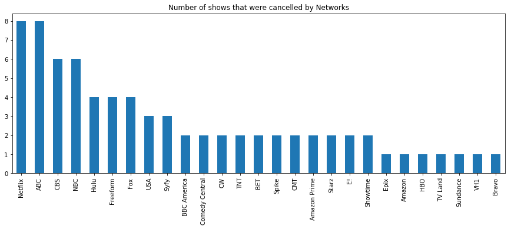

```python
plt.figure(figsize=(15,5))
plt.title('Number of shows that were cancelled by Networks')
canceled['tv_network'].value_counts().plot(kind='bar')
```

### Which TV networks have the most renewals?

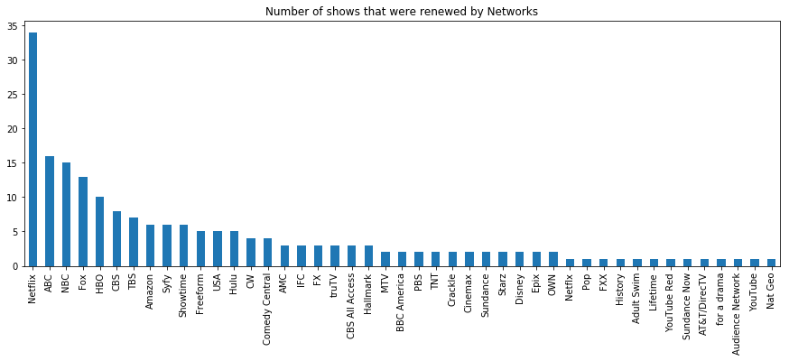

```python
plt.figure(figsize=(15,5))
plt.title('Number of shows that were renewed by Networks')
renewed['tv_network'].value_counts().plot(kind='bar')
```

### What is the total number of twitter followers for all of a networks of renewed shows?

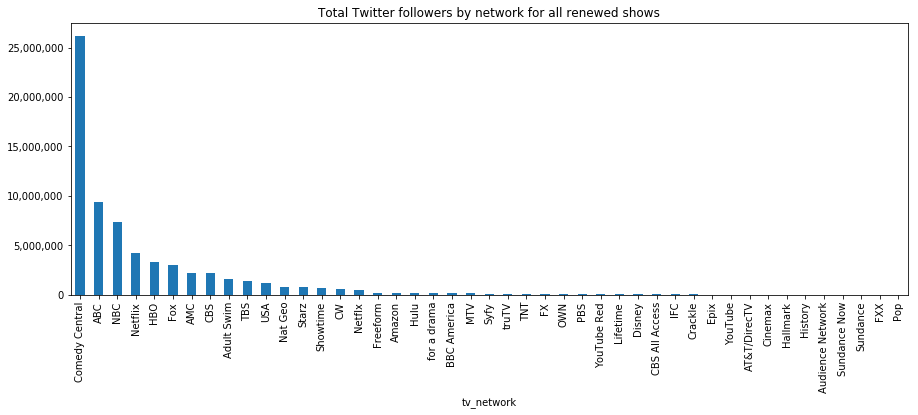

```python
ax = renewed.groupby('tv_network')['twitter_followers'].sum().sort_values(ascending=False).plot(kind='bar', figsize=(15, 5))
ax.set_title("Total Twitter followers by network for all renewed shows")

ax.get_yaxis().set_major_formatter(plt.FuncFormatter(lambda x, loc: "{:,}".format(int(x))))
```

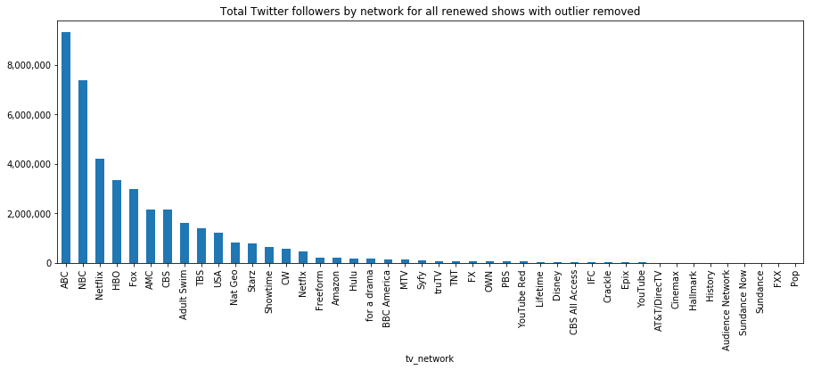

```python
test = renewed.groupby('tv_network')['twitter_followers'].sum().sort_values(ascending=False)

ax = test.drop(labels=['Comedy Central']).plot(kind='bar', figsize=(15, 5))
ax.set_title("Total Twitter followers by network for all renewed shows with outlier removed")

ax.get_yaxis().set_major_formatter(plt.FuncFormatter(lambda x, loc: "{:,}".format(int(x))))
```

```python
renewed[(renewed['tv_network']=='Comedy Central') & (renewed['twitter_followers']>=500000)]
```

|  | tv_show_name | tv_network | imdb_score | imdb_score_num_users | avg_review_score | pos_review_sent | neg_review_sent | neut_review_sent | pos_revTitle_sent | neg_revTitle_sent | ... | twitter_followers | twitter_screenname | top_rated_rank | genres | story_keywords | runtime | tv_rating | release_date | country | langauge |
| --- | --- | --- | --- | --- | --- | --- | --- | --- | --- | --- | --- | --- | --- | --- | --- | --- | --- | --- | --- | --- | --- |
| 22 | Tosh.0 | Comedy Central | 7.3 | 13890 | 3.9 | 36 | 15 | 10 | 0 | 15 | ... | 26064235.0 | danieltosh | NaN | [Comedy] | [pixelated nudity, vomiting, 2000s, 2010s, ref... | 00:30:00 | TV-14 | 2009-06-04 | [USA] | [English] |

1 rows × 21 columns

```python
renewed[(renewed['tv_network']=='ABC') & (renewed['twitter_followers']>=500000)]
```

|  | tv_show_name | tv_network | imdb_score | imdb_score_num_users | avg_review_score | pos_review_sent | neg_review_sent | neut_review_sent | pos_revTitle_sent | neg_revTitle_sent | ... | twitter_followers | twitter_screenname | top_rated_rank | genres | story_keywords | runtime | tv_rating | release_date | country | langauge |
| --- | --- | --- | --- | --- | --- | --- | --- | --- | --- | --- | --- | --- | --- | --- | --- | --- | --- | --- | --- | --- | --- |
| 24 | Dancing with the Stars | ABC | 4.8 | 8926 | 6.8 | 38 | 11 | 10 | 1 | 9 | ... | 1064964.0 | DancingABC | NaN | [Family, Game-Show, Music, Reality-TV] | [2000s, 2010s, 21st century, weekly eliminatio... | 01:00:00 | TV-PG | 2005-06-01 | [USA] | [English] |
| 27 | How to Get Away with Murder | ABC | 8.2 | 103205 | 5.4 | 35 | 31 | 9 | 1 | 30 | ... | 919151.0 | HowToGetAwayABC | NaN | [Crime, Drama, Mystery, Thriller] | [law student, gay character, legal drama, cour... | 00:43:00 | TV-14 | 2014-09-25 | [USA] | [English, Spanish] |
| 57 | Grey's Anatomy | ABC | 7.6 | 210734 | 3.4 | 31 | 28 | 16 | 1 | 29 | ... | 4690386.0 | GreysABC | NaN | [Drama, Romance] | [surgeon, hospital, lesbian, work romance, sur... | 00:41:00 | TV-14 | 2005-03-27 | [USA] | [English] |
| 166 | American Idol | ABC | 4.2 | 20453 | 4.0 | 45 | 18 | 12 | 1 | 18 | ... | 2038939.0 | AmericanIdol | NaN | [Game-Show, Music, Reality-TV] | [2010s, 2000s, singing contest, pop music, mus... | 00:42:00 | TV-PG | 2002-06-11 | [USA] | [English] |

4 rows × 21 columns

This is a bit misleading as TOSH.0 is a bit of an outlier. Daniel Tosh, the host of the show, has a twitter following of 26 Million.

ABC has the next highest following with headliners like Grey's Anatomy, American Idol and How to Get Away with Murder.

### What is the total number of twitter followers for all of a networks of canceled shows?

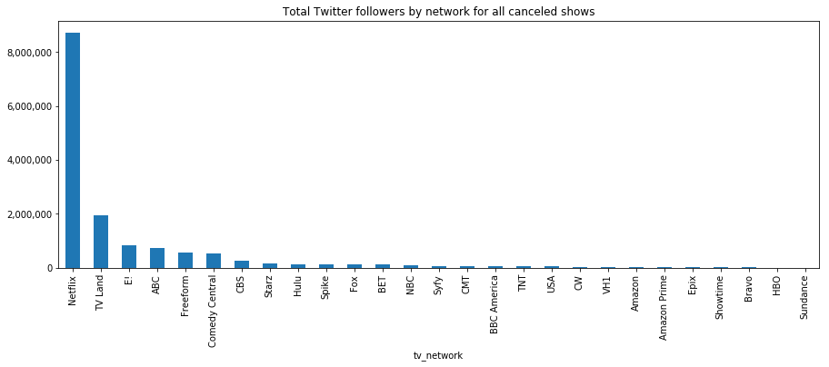

```python
ax = canceled.groupby('tv_network')['twitter_followers'].sum().sort_values(ascending=False).plot(kind='bar', figsize=(15, 5))
ax.set_title("Total Twitter followers by network for all canceled shows")

ax.get_yaxis().set_major_formatter(plt.FuncFormatter(lambda x, loc: "{:,}".format(int(x))))
```

```python
canceled[(canceled['tv_network']=='Netflix') & (canceled['twitter_followers']>=100000)]
```

|  | tv_show_name | tv_network | imdb_score | imdb_score_num_users | avg_review_score | pos_review_sent | neg_review_sent | neut_review_sent | pos_revTitle_sent | neg_revTitle_sent | ... | twitter_followers | twitter_screenname | top_rated_rank | genres | story_keywords | runtime | tv_rating | release_date | country | langauge |
| --- | --- | --- | --- | --- | --- | --- | --- | --- | --- | --- | --- | --- | --- | --- | --- | --- | --- | --- | --- | --- | --- |
| 17 | Sense8 | Netflix | 8.4 | 123035 | 5.1 | 35 | 27 | 13 | 2 | 18 | ... | 338765.0 | sense8 | NaN | [Drama, Mystery, Sci-Fi, Thriller] | [psychic connection, shared experiences, telep... | 01:00:00 | TV-MA | 2015-06-05 | [USA] | [English] |
| 35 | Chelsea | Netflix | 6.2 | 1778 | 5.2 | 18 | 15 | 6 | 3 | 12 | ... | 8260297.0 | chelseahandler | NaN | [Comedy, Talk-Show] | [woman, non fiction] | 00:30:00 | TV-MA | 2016-05-11 | [USA] | [English] |

2 rows × 21 columns

Once again, there is a bit of an outlier in the twitter following of Netflix shows. Chelsea is a show hosted by Chelsea Handler and her twitter following is 8.26 Million. The next highest twitter following is Sense8.

```python
renewedWithOutOutlier = test.drop(labels=['Comedy Central']).mean()
canceledWithOutlier = canceled.twitter_followers.mean()
```

```python
print("The average number of twitter followers for renewed TV shows, with outliers removed is %s" %round(renewedWithOutOutlier, 2))
```

```
The average number of twitter followers for renewed TV shows, with outliers removed is 924488.02
```

```python
print("The average number of twitter followers for canceled TV shows, with outliers removed is %s" %round(canceledWithOutlier, 2))
```

[output not shown]

### Is there a correlation to the average positive/negative sentiment to a renewed shows?

```python
renewedPos  = renewed['pos_review_sent'].sum()
renewedNeg  = renewed['neg_review_sent'].sum()
renewedNuet = renewed.neut_review_sent.sum()

totalNumberOfReviews = renewedPos+renewedNeg+renewedNuet

renewedPos  = round((renewedPos/totalNumberOfReviews)*100, 2)
renewedNeg  = round((renewedNeg/totalNumberOfReviews)*100, 2)
renewedNuet = round((renewedNuet/totalNumberOfReviews)*100, 2)

print("The total percentage of positive\\negative\\neutral review sentiment for renewed shows are: %s%%, %s%%, %s%%" %(renewedPos, renewedNeg, renewedNuet))
```

```
The total percentage of positive\negative\neutral review sentiment for renewed shows are: 53.93%, 25.59%, 20.49%
```

```python
canceledPos  = canceled['pos_review_sent'].sum()
canceledNeg  = canceled['neg_review_sent'].sum()
canceledNuet = canceled.neut_review_sent.sum()

totalNumberOfReviews = canceledPos+canceledNeg+canceledNuet

canceledPos  = round((canceledPos/totalNumberOfReviews)*100, 2)
canceledNeg  = round((canceledNeg/totalNumberOfReviews)*100, 2)
canceledNuet = round((canceledNuet/totalNumberOfReviews)*100, 2)

print("The total number of positive\\negative\\neutral review sentiment for renewed shows are: %s%%, %s%%, %s%%" %(canceledPos, canceledNeg, canceledNuet))
```

[output not shown]

## Descriptive Analytics

##### Helper Functions

```python
# This function extracts all the review texts from the list of dictionaries
def returnText(data, typeText):
    reviewText = []

    if typeText == "review":
        searchFor = 'review_text'
    elif typeText == "title":
        searchFor = 'review_title'
    else:
        return "Error: Only 'review' or 'title' are valid inputs for typeText"

    for i in range(len(data)):
        reviewData = data[i]['imdb_reviews']

        for n in range(len(reviewData)):
            reviewText.append(str(reviewData[n][searchFor]))

    return reviewText

# function to return words counts for each review
def returnWordCount(data):

    word_count = []

    for i in range(len(data)):
        word_count.append(len(data[i].split()))

    return word_count

# Function to place 1000s seperator within a given number.
def place_value(num):
    return ("{:,}".format(num))

# This is a function for data cleaning
def text_processing(review):
    # what if you have additional stopwords to be removed
    tokens = str(review)

    #lowecases
    tokens = tokens.lower()

    # Remove useless numbers and alphanumerical words
    tokens = re.sub("[^a-zA-Z0-9]", " ", tokens)

    #tokenization or word split
    tokens = word_tokenize(tokens)

    #get stemming words or lemmas
    wordnet_lemmatizer = WordNetLemmatizer()
    tokens = (wordnet_lemmatizer.lemmatize(word) for word in tokens)

    #additional stopwrods
    more_stopwords = set(('show', 'character', 'episode', 'series', 'really', 'get', 'first', 'people', 'also', 'two', 'season', 'one'))
    extra_stoplist = set(stopwords.words('english')) | more_stopwords
    tokens = (word for word in tokens if word not in extra_stoplist)

    # Filter non-alphanumeric characters from tokens
    tokens = (word for word in tokens if word.isalpha())

    #remove short words
    tokens = (word for word in tokens if len(word) > 3)

    return tokens
```

### Average word counts for reviews on renewed\canceled TV shows.

```python
renewedReviewText = returnText(renewedIMDbReviews, 'review')
canceledReviewText = returnText(canceledIMDbReviews, 'review')
renewedReviewTitle = returnText(renewedIMDbReviews, 'title')
canceledReviewTitle = returnText(canceledIMDbReviews, 'title')

renewedWordCounts = returnWordCount(renewedReviewText)
canceledWordCounts = returnWordCount(canceledReviewText)

renewedWordCounts = round(sum(renewedWordCounts)/len(renewedWordCounts), 2)
canceledWordCounts = round(sum(canceledWordCounts)/len(canceledWordCounts), 2)

print("Average word counts for renewed show reviews is %s: " %renewedWordCounts)
print("Average word counts for canceled show reviews is %s: " %canceledWordCounts)
print()
print("While the word counts are similar, we need to consider the amount of reviews as there are more renewed shows vs canceled shows. The total number of words within renewed reviews is %s while the total number of words for canceled shows is %s. When we consider the number of reviews within each category we see that the canceled shows have a larger word count in it's reviews than the renewed shows." %(place_value(sum(returnWordCount(renewedReviewText))), place_value(sum(returnWordCount(canceledReviewText)))))
```

[output not shown]

### Word Frequency Analysis

##### Frequency Distribution

```python
rTxtTokens = text_processing(renewedReviewText)
cTxtTokens = text_processing(canceledReviewText)

rTitleTokens = text_processing(renewedReviewTitle)
cTitleToken = text_processing(canceledReviewTitle)
```

```python
rTxtDist = nltk.FreqDist(rTxtTokens)
cTxtDist = nltk.FreqDist(cTxtTokens)

rTitleDist = nltk.FreqDist(rTitleTokens)
cTitleDist = nltk.FreqDist(cTitleToken)
```

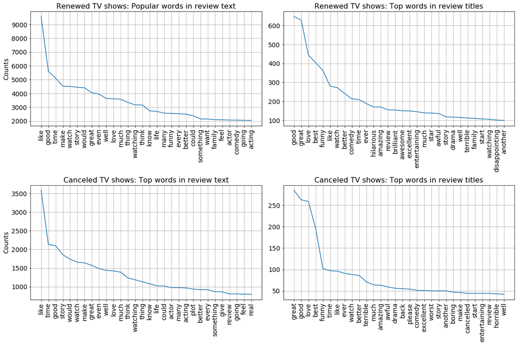

```python
# I was not able to do subplots using fdist.plot(). Thus, the method below breaks apart the x and y values (word, freq) of the distribution and plots them.
# This idea was modified from section 10.3 from the following source: http://www.tulane.edu/~howard/NLP/textstats.html

ldata = [rTxtDist, rTitleDist, cTxtDist, cTitleDist]
titles = ['Renewed TV shows: Popular words in review text', 'Renewed TV shows: Top words in review titles', 'Canceled TV shows: Top words in review text', 'Canceled TV shows: Top words in review titles']

limit = 30
plt.figure(figsize=(16, 20))

for (pane, test) in enumerate(ldata):
    if pane == 0:
        XY = rTxtDist.items()
    elif pane == 1:
        XY = rTitleDist.items()
    elif pane == 2:
        XY = cTxtDist.items()
    elif pane == 3:
        XY = cTitleDist.items()


    XY = sorted(XY, key=lambda pair: pair[1], reverse=True)
    XY.sort(key=lambda pair: pair[1], reverse=True)

    X = [x for (x,y) in XY[:limit]]
    Y = [y for (x,y) in XY[:limit]]

    nX = range(len(X))

    plt.subplot(4, 2, pane+1)
    plt.plot(nX, Y, label='counts to tokens')
    plt.xticks(nX, X, rotation='vertical', fontsize='14')
    plt.yticks(fontsize='14')

    if pane == 0: plt.ylabel('Counts', fontsize='14')
    elif pane %2 == 0:
        #plt.xlabel('Tokens', fontsize='14')
        plt.ylabel('Counts', fontsize='14')

    plt.title(titles[pane], fontsize='16')
    plt.grid()
plt.tight_layout()
plt.show()
```

The review title are actually a bit more telling and show the intent a bit better. However, what I find interesting is that the popular words when compared to renewed and canceled review text\titles is very similar.

##### Bi-Grams

```python
rTxtTokens = text_processing(renewedReviewText)
cTxtTokens = text_processing(canceledReviewText)

rTitleTokens = text_processing(renewedReviewTitle)
cTitleToken = text_processing(canceledReviewTitle)
```

```python
# Create bigrams
rTxt_bi = nltk.bigrams(rTxtTokens)
cTxt_bi = nltk.bigrams(cTxtTokens)

rTitle_bi = nltk.bigrams(rTitleTokens)
cTitle_bi = nltk.bigrams(cTitleToken)

# Distribution of bigrams
dist_rTxt_bi  = nltk.FreqDist(rTxt_bi)
dist_cTxt_bi  = nltk.FreqDist(cTxt_bi)

dist_rTitle_bi = nltk.FreqDist(rTitle_bi)
dist_cTitle_bi = nltk.FreqDist(cTitle_bi)
```

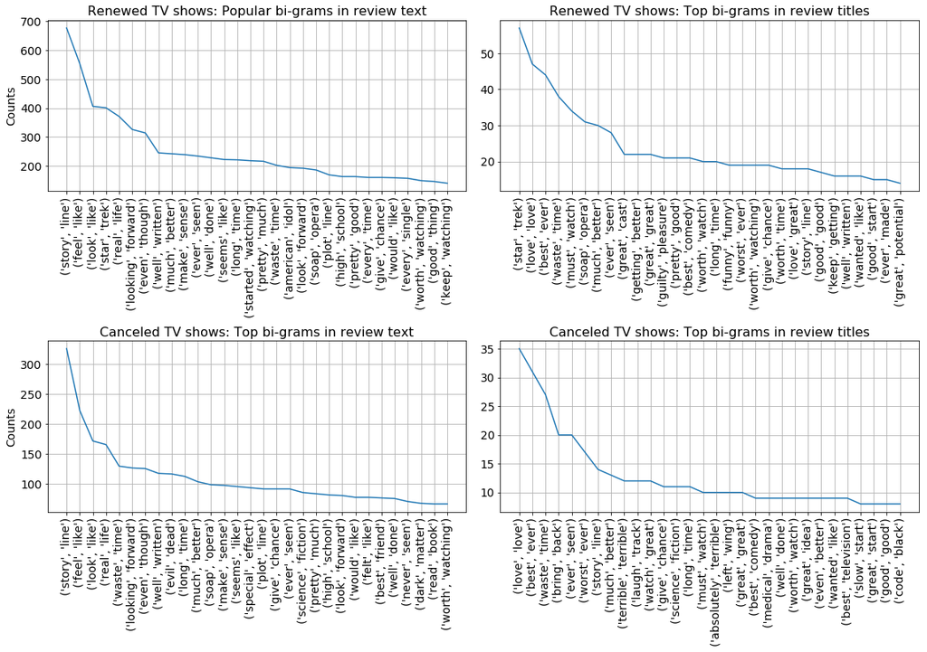

```python
# I was not able to do subplots using fdist.plot(). Thus, the method below breaks apart the x and y values (word, freq) of the distribution and plots them.
# This idea was modified from section 10.3 from the following source: http://www.tulane.edu/~howard/NLP/textstats.html

ldata = [dist_rTxt_bi, dist_rTitle_bi, dist_cTxt_bi, dist_cTitle_bi]
titles = ['Renewed TV shows: Popular bi-grams in review text', 'Renewed TV shows: Top bi-grams in review titles', 'Canceled TV shows: Top bi-grams in review text', 'Canceled TV shows: Top bi-grams in review titles']

limit = 30
plt.figure(figsize=(16, 20))

for (pane, test) in enumerate(ldata):
    if pane == 0:
        XY = dist_rTxt_bi.items()
    elif pane == 1:
        XY = dist_rTitle_bi.items()
    elif pane == 2:
        XY = dist_cTxt_bi.items()
    elif pane == 3:
        XY = dist_cTitle_bi.items()


    XY = sorted(XY, key=lambda pair: pair[1], reverse=True)
    XY.sort(key=lambda pair: pair[1], reverse=True)

    X = [x for (x,y) in XY[:limit]]
    Y = [y for (x,y) in XY[:limit]]

    nX = range(len(X))

    plt.subplot(4, 2, pane+1)
    plt.plot(nX, Y, label='counts to tokens')
    plt.xticks(nX, X, rotation='vertical', fontsize='14')
    plt.yticks(fontsize='14')

    if pane == 0: plt.ylabel('Counts', fontsize='14')
    elif pane %2 == 0:
        #plt.xlabel('Tokens', fontsize='14')
        plt.ylabel('Counts', fontsize='14')

    plt.title(titles[pane], fontsize='16')
    plt.grid()
plt.tight_layout()
plt.show()
```

The bi-grams are a bit more telling then the word frequencies were. Looking at the bi-grams for the renewed shows, we can see terms like: must watch, looking forward, best ever, ever seen, etc. However, the bi-grams for the canceled shows have terms like: waste time (in both, but more frequent in canceled shows), worst ever, absolutely terrible.

### Word Clouds

##### Helper Functions

```python
# This is a function to generate a wordcloud. I made it so I wouldn't have to copy and paste the code evertime I wanted to make a new worldcloudabs.

def gen_wordcloud(data, w, h, type_dist, words= None, title = None):
    """This function is used to generate a Word Cloud from frequency dictionary.

    Parameters:
    data (dict): This is a dictionary that contains the word as a key and count as a value

    w (float): Width of the figure

    h (float): Height of the figure

    type_dist (string): The type of data that is passed in . Must be 'f' for frequency distribution and 'b' for bigrams. Anything else throws an error.

    words (list): A list of words to be removed from the passed in dictionary. This is optional.

    title (string): The title of the Word Cloud. This is optional.

    """

    if type_dist == "f":
        # Copy the passed in freq dict so that we don't change it if stopwords are passed in.
        tempDict = dict(data)

        # If stopwords are passed into function, remove them from the temporary dictionary
        if words:

            # If word is 4 characters or less, add it to the stopwords list
            words.extend(stopwords.words('english'))
            words.extend(word for word in data.keys() if len(word) <= 4)

            for i in words:
                if i in tempDict.keys():
                    tempDict.pop(i, None)

    elif type_dist== "b":
        copyDict = dict(data)
        tempDict = defaultdict(int)

        if words:
            words.extend(stopwords.words('english'))
            #words.extend(word[0] for word in copyDict.keys() if len(word[0]) <= 4)
            #words.extend(word[1] for word in copyDict.keys() if len(word[1]) <= 4)
            for i in words:
                for n in list(copyDict.keys()):
                    if (i == n[0]) | (i == n[1]):
                        copyDict.pop((n))

        for i in list(copyDict.keys()):
            tempDict['_'.join(i)] = copyDict[i]
    else:
        print("Error: did not provide correct type")
        return

    # Set up word cloud settings and generate from frequencies
    wordcloud = WordCloud(
        background_color='white',
        max_words=250,
        width=1920,
        height=1080,
        ).generate_from_frequencies(tempDict)

    fig = plt.figure(figsize=(w, h), dpi=150)
    plt.axis("off")

    # Set title if passed into function
    if title:
        plt.title(title, fontsize=12)

    plt.imshow(wordcloud)
    plt.show()
```

##### Word frequency wordcloud for review text of renewed TV shows

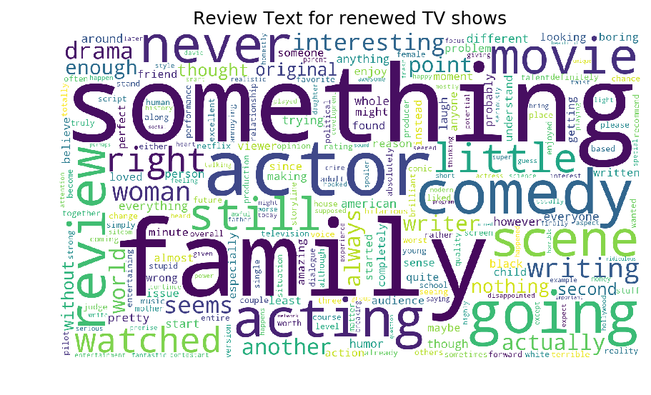

```python
# Additional stopwords to remove from frequency distribution
words = ['time', 'good', 'like', 'watch', 'make', 'even', 'much', 'story', 'thing', 'would', 'watching', 'could', 'great', 'funny', 'think', 'every', 'better']

# Generate wordcloud
gen_wordcloud(rTxtDist, 7, 5, type_dist="f",  words=words, title="Review Text for renewed TV shows")
```

##### Word frequency wordcloud for review text of canceled TV shows

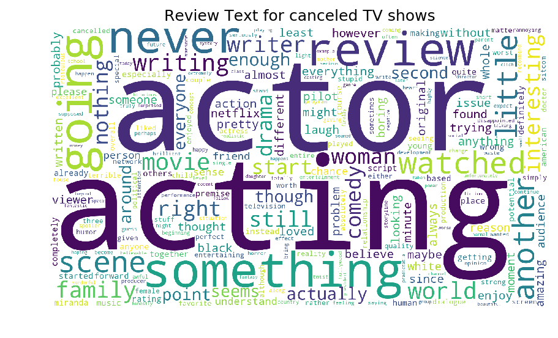

```python
# Additional stopwords to remove from frequency distribution
words = ['time', 'good', 'like', 'watch', 'well', 'make', 'even', 'much', 'story', 'thing', 'would', 'watching','could', 'great', 'funny', 'think', 'every', 'better']

# Generate wordcloud
gen_wordcloud(cTxtDist, 7, 5, type_dist="f", words=words, title="Review Text for canceled TV shows")
```

##### Bi-Gram wordcloud for review text of renewed TV shows

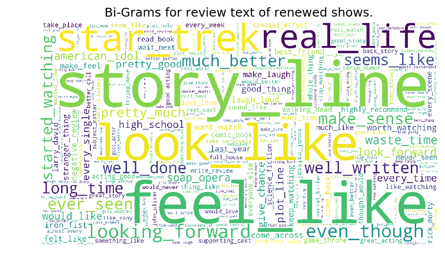

```python
gen_wordcloud(dist_rTxt_bi, 7, 5, type_dist="b", title="Bi-Grams for review text of renewed shows.")
```

##### Bi-Gram wordcloud for review text of canceled TV shows

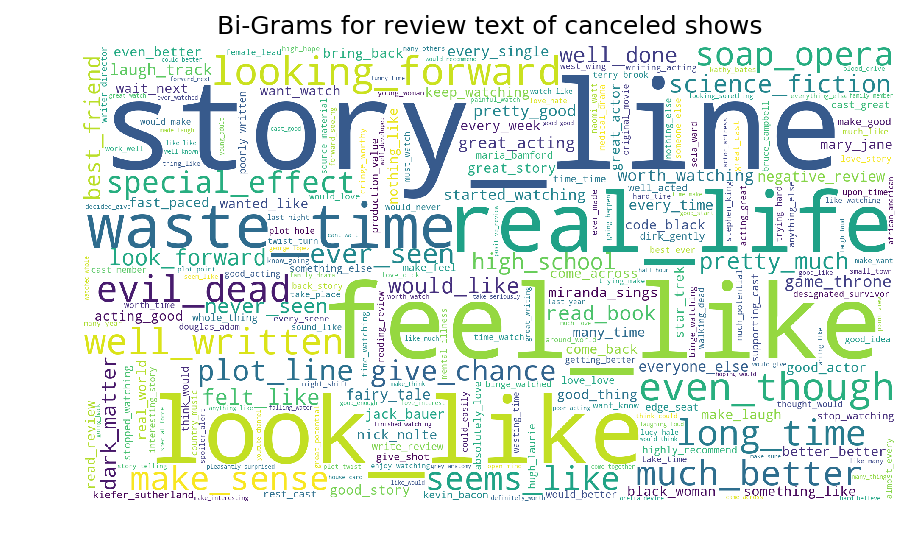

```python
gen_wordcloud(dist_cTxt_bi, 7, 5, type_dist="b", title="Bi-Grams for review text of canceled shows")
```

## Special Case: Rescued TV show

There was one TV show that was canceled by its parent network and later rescued by different network. I wanted to look into the review text and numbers to see what sets it apart. The shows information is below:

- Title: Brooklyn Nine-Nine
- IMDB Score: 8.4
- Number of users voted: 144,529
- Average review score: 8.9
- Positive review sentiment: 74.67%
- Negative review sentiment: 12%
- Neutral review sentiment: 13.33%
- Twitter Followers: 607,086
- IMDB Top 250 Rank: 238

```python
cIMDBScore    = round(canceled.imdb_score.mean(), 1)
cIMDBNumVotes = place_value(round(canceled.imdb_score_num_users.mean(), 0))
cAvgRevScore  = round(canceled.avg_review_score.mean(), 1)
cAvgTwitFoll  = place_value(round(canceled.twitter_followers.mean()))

total = sum(canceled.pos_review_sent)+ sum(canceled.neg_review_sent) + sum(canceled.neut_review_sent)
pos   = sum(canceled.pos_review_sent)
neg   = sum(canceled.neg_review_sent)
neut  = sum(canceled.neut_review_sent)

cPerPos  = (pos/total)*100
cPerNeg  = (neg/total)*100
cPerNeut = (neut/total) *100

cPerPos  = round(cPerPos, 2)
cPerNeg  = round(cPerNeg, 2)
cPerNeut = round(cPerNeut, 2)

print("Review Summary of Canceled Shows: ")
print("-"*50)
print()
print("*     Avg IMDB score: ------------------ %s"   %cIMDBScore)
print("*     Avg IMDB Number of Votes: -------- %s"   %cIMDBNumVotes)
print("*     Avg IMDB review score: ----------- %s"   %cAvgRevScore)
print("*     Avg Twitter Following: ----------- %s"   %cAvgTwitFoll)
print("*     Avg percent of positive sentiment: %s%%" %cPerPos)
print("*     Avg percent of negative sentiment: %s%%" %cPerNeg)
print("*     Avg percent of neutral sentiment:  %s%%" %cPerNeut)
```

```
Review Summary of Canceled Shows:
--------------------------------------------------

*     Avg IMDB score: ------------------ 7.0
*     Avg IMDB Number of Votes: -------- 16,225.0
*     Avg IMDB review score: ----------- 6.5
*     Avg Twitter Following: ----------- 223,347.0
*     Avg percent of positive sentiment: 53.85%
*     Avg percent of negative sentiment: 26.81%
*     Avg percent of neutral sentiment:  19.34%
```

```python
canceled[canceled.top_rated_rank > 1]
```

|  | tv_show_name | tv_network | imdb_score | imdb_score_num_users | avg_review_score | pos_review_sent | neg_review_sent | neut_review_sent | pos_revTitle_sent | neg_revTitle_sent | ... | twitter_followers | twitter_screenname | top_rated_rank | genres | story_keywords | runtime | tv_rating | release_date | country | langauge |
| --- | --- | --- | --- | --- | --- | --- | --- | --- | --- | --- | --- | --- | --- | --- | --- | --- | --- | --- | --- | --- | --- |
| 30 | Ash vs Evil Dead | Starz | 8.5 | 56082 | 9.7 | 37 | 22 | 16 | 1 | 6 | ... | 113415.0 | AshvsEvilDead | 204.0 | [Action, Comedy, Fantasy, Horror] | [evil dead, chainsaw, splatter, fourth part, s... | 00:30:00 | TV-MA | 2015-10-31 | None | None |
| 33 | The Expanse | Syfy | 8.4 | 68694 | 9.7 | 58 | 5 | 12 | 4 | 7 | ... | 52453.0 | ExpanseSYFY | 239.0 | [Drama, Mystery, Sci-Fi, Thriller] | [false flag operation, dead girlfriend, shooto... | 01:00:00 | TV-14 | 2015-11-23 | [Canada, USA] | [English] |

2 rows × 21 columns

### Word Cloud for rescued review text

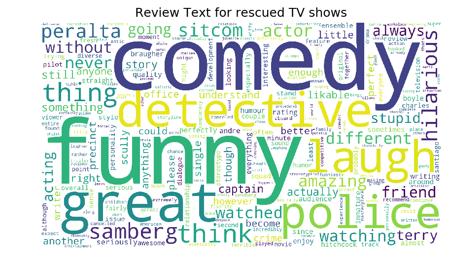

```python
rescuedReviewText = returnText(rescuedIMDbReviews, 'review')
rsTxtTokens = text_processing(rescuedReviewText)
rsTxtDist = nltk.FreqDist(rsTxtTokens)

# Additional stopwords to remove from frequency distribution
words = ['brooklyn', 'nine', 'like', 'would', 'every', 'watch', 'good', 'make']

# Generate wordcloud
gen_wordcloud(rsTxtDist, 7, 5, words=words, type_dist="f", title="Review Text for rescued TV shows")
```

### Bi-Gram for rescued review text

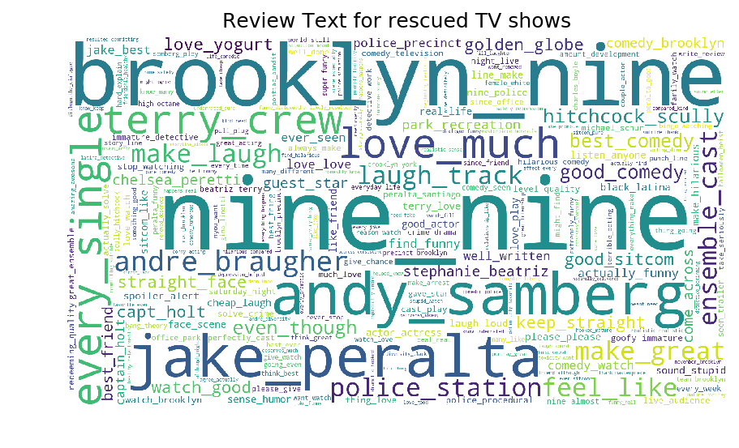

```python
# Create bigrams
rTxtTokens = text_processing(renewedReviewText)
rTxt_bi = nltk.bigrams(rTxtTokens)
dist_rTxt_bi  = nltk.FreqDist(rTxt_bi)


rsTxtTokens = text_processing(rescuedReviewText)
reTxt_bi = nltk.bigrams(rsTxtTokens)
dist_reTxt_bi = nltk.FreqDist(reTxt_bi)

# Generate wordcloud
gen_wordcloud(dist_reTxt_bi, 7, 5, type_dist="b", title="Review Text for rescued TV shows")
```

### Results

When looking at the average sentiment across all shows that were canceled, we can see that the average positive sentiment is considerably lower than that of Brooklyn Nine-Nine, 53.85% compared to 74.67% and higher on the negative sentiment side, 26.81% compared to 12%.

# Content Analysis

I decided to try and do text classification on the review text for both renewed and canceled tv shows to see if we can try to predict renewal\cancellation from the review text found in IMDB. To do this I need to combine the to datasets and assign them a classification. I will assign a 1 to renewed shows and a 0 for canceled shows. For this analysis, I will be ignoring the rescued dataset.

## Combine review texts and assign to category

```python
# Create DataFrame for renewed and canceled review text
# There is 62% more number of reviews for renewed tv shows since there were more shows that were renewed.
# We want to have similar amounts of data in both, so I am takeing a random sampling of 37.71% which gives
# me the same amount of reviews for renewed review text

renewedRevDF = pd.DataFrame(renewedReviewText)
renewedRevDF = renewedRevDF.sample(frac=.3771).reset_index(drop=True)
canceledRevDF = pd.DataFrame(canceledReviewText)

# Set the classification value, 1 for renewed and 0 for canceled
renewedRevDF[1]  = 1
canceledRevDF[1] = 0

# Combine the to sets of review text and classification
all_data = pd.concat([renewedRevDF, canceledRevDF], ignore_index=True)

# randomize 100% of the combined data
all_data = all_data.sample(frac=1).reset_index(drop=True)

# save the data
all_data.to_csv('data/sampledReviewData.csv', header=False, index=False)
```

```python
# Create DataFrame for renewed and canceled review text
# There is 62% more number of reviews for renewed tv shows since there were more shows that were renewed.
# We want to have similar amounts of data in both, so I am takeing a random sampling of 37.71% which gives
# me the same amount of reviews for renewed review text

renewedTiDF = pd.DataFrame(renewedReviewTitle)
renewedTiDF = renewedTiDF.sample(frac=.3771).reset_index(drop=True)
canceledTiDF = pd.DataFrame(canceledReviewTitle)

# Set the classification value, 1 for renewed and 0 for canceled
renewedTiDF[1]  = 1
canceledTiDF[1] = 0

# Combine the to sets of review text and classification
all_data = pd.concat([renewedTiDF, canceledTiDF], ignore_index=True)

# randomize 100% of the combined data
all_data = all_data.sample(frac=1).reset_index(drop=True)

# save the data
all_data.to_csv('data/sampledRevTitleData.csv', header=False, index=False)
```

## Data Pre-Processing and Feature Selection

```python
#Step 1. Import the data
print("Step 1. Import Data ... ")

# first column
rev_text_data = []
title_text_data = []

# second colummn
rev_labels = []
title_labels = []

# both columns
rev_all_text_data = []
title_all_text_data = []

openfile = open('data/sampledReviewData.csv', 'r')

r = csv.reader(openfile)

for i in r:
    rev_all_text_data.append(i)
    rev_text_data.append(i[0])
    rev_labels.append(i[1])

openfile.close()


openfile = open('data/sampledRevTitleData.csv', 'r')

r = csv.reader(openfile)

for i in r:
    title_all_text_data.append(i)
    title_text_data.append(i[0])
    title_labels.append(i[1])

openfile.close()


#Step 2. Text preprocessing
print("Step 2. Text preprocessing ... ")
tfidf_vectorizer = TfidfVectorizer(decode_error ='ignore', stop_words='english', token_pattern=r'\w*[a-zA-Z]')
tfidf = tfidf_vectorizer.fit_transform(rev_text_data)

#Step 3. Building a predictive text classification model
print("Step 3. Split validation & Building a predictive text classification model ... ")
x_train, x_test, y_train, y_test = train_test_split(rev_text_data, rev_labels, test_size=0.2, random_state=0)
print(len(x_train), len(y_train), len(x_test), len(y_test))

X_train = tfidf_vectorizer.fit_transform(x_train)
X_test = tfidf_vectorizer.transform(x_test)

nb = MultinomialNB().fit(X_train, y_train)

predicted = nb.predict(X_test)
np.mean(predicted == y_test)
```

```
Step 1. Import Data ...
Step 2. Text preprocessing ...
Step 3. Split validation & Building a predictive text classification model ...
7473 7473 1869 1869
```

```
0.8255751738897806
```

## Text Classification Models

### Naive Bayes Model

##### Grid Search

```python
nb_pipeline = Pipeline([('tfidf', TfidfVectorizer(decode_error ='ignore', stop_words='english')), ('clf', MultinomialNB())])

parameters = {'tfidf__ngram_range': [(1, 1), (1, 2), (1, 3)],
              'tfidf__min_df': [1, 2, 5],
              'tfidf__max_df': [0.9, 0.8, 0.7],
              'clf__alpha': (0.01, 0.001, 1),
}

gs_clf = GridSearchCV(nb_pipeline, parameters)
gs_clf.fit(x_train, y_train)
```

```
GridSearchCV(cv='warn', error_score='raise-deprecating',
       estimator=Pipeline(memory=None,
     steps=[('tfidf', TfidfVectorizer(analyzer='word', binary=False, decode_error='ignore',
        dtype=<class 'numpy.float64'>, encoding='utf-8', input='content',
        lowercase=True, max_df=1.0, max_features=None, min_df=1,
        ngram_range=(1, 1), norm='l2', preprocessor=None, smooth_idf=True,...rue,
        vocabulary=None)), ('clf', MultinomialNB(alpha=1.0, class_prior=None, fit_prior=True))]),
       fit_params=None, iid='warn', n_jobs=None,
       param_grid={'tfidf__ngram_range': [(1, 1), (1, 2), (1, 3)], 'tfidf__min_df': [1, 2, 5], 'tfidf__max_df': [0.9, 0.8, 0.7], 'clf__alpha': (0.01, 0.001, 1)},
       pre_dispatch='2*n_jobs', refit=True, return_train_score='warn',
       scoring=None, verbose=0)
```

```python
gs_clf.best_score_
```

```
0.794593871269905
```

```python
for param_name in sorted(parameters.keys()):
    print(("%s: %r" % (param_name, gs_clf.best_params_[param_name])))
```

```
clf__alpha: 1
tfidf__max_df: 0.9
tfidf__min_df: 2
tfidf__ngram_range: (1, 1)
```

#### For Review Text

```python
# combining feature engineering and model building
nb_pipeline = Pipeline([('tfidf', TfidfVectorizer(decode_error ='ignore', stop_words='english', token_pattern=r'\w*[a-zA-Z]', max_df=0.9, min_df=2, ngram_range=(1,1))), ('clf', MultinomialNB())])

nb_pipeline = nb_pipeline.fit(x_train, y_train)
predicted = nb_pipeline.predict(x_test)
np.mean(predicted == y_test)
```

```
0.8362760834670947
```

```python
print('\n overall accuracy:')
print(metrics.accuracy_score(y_test, predicted))

print('\n Here is the classification report:')
print(metrics.classification_report(y_test, predicted))
```

```
 overall accuracy:
0.8362760834670947

 Here is the classification report:
              precision    recall  f1-score   support

           0       0.82      0.87      0.85       975
           1       0.85      0.80      0.82       894

   micro avg       0.84      0.84      0.84      1869
   macro avg       0.84      0.83      0.84      1869
weighted avg       0.84      0.84      0.84      1869
```

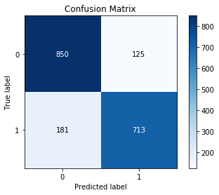

```python
skplt.metrics.plot_confusion_matrix(y_true=np.array(y_test), y_pred=predicted)
plt.show()
```

#### For Review Titles

```python
tfidf_vectorizer = TfidfVectorizer(decode_error ='ignore', stop_words='english', token_pattern=r'\w*[a-zA-Z]')
tfidf = tfidf_vectorizer.fit_transform(title_text_data)

x1_train, x1_test, y1_train, y1_test = train_test_split(title_text_data, title_labels, test_size=0.2, random_state=0)
print(len(x1_train), len(y1_train), len(x1_test), len(y1_test))

# combining feature engineering and model building
nb_pipeline = Pipeline([('tfidf', TfidfVectorizer(decode_error ='ignore', stop_words='english', token_pattern=r'\w*[a-zA-Z]')), ('clf', MultinomialNB())])

nb_pipeline = nb_pipeline.fit(x1_train, y1_train)
predicted = nb_pipeline.predict(x1_test)
np.mean(predicted == y1_test)
```

```
7473 7473 1869 1869
```

```
0.6131621187800963
```

### KNN

```python
knn_pipeline = Pipeline([('tfidf', TfidfVectorizer(decode_error ='ignore', stop_words='english', token_pattern=r'\w*[a-zA-Z]')), ('clf', KNeighborsClassifier())])

knn_pipeline = knn_pipeline.fit(x_train, y_train)
predicted = knn_pipeline.predict(x_test)
np.mean(predicted == y_test)
```

```
0.5088282504012841
```

### SVM

```python
svm_pipeline = Pipeline([('tfidf', TfidfVectorizer(decode_error ='ignore', stop_words='english', token_pattern=r'\w*[a-zA-Z]')), ('clf', SVC(kernel='linear', probability=True))])
svm_pipeline = svm_pipeline.fit(x_train, y_train)
predicted = svm_pipeline.predict(x_test)
np.mean(predicted == y_test)
```

```
0.7929373996789727
```

### Summary of Classification Models

Out of curiosity, I wanted to see the difference in using text from reviews vs the text from review titles to see which would be a better model. The model built from review text was 82.5% accurate while the model built from review titles was 61.3% accurate.

The grid search did give us a slightly better accuracy from 82.5% to 83.6%.

I also ran the KNN and the SVM models and found that the Naive Bayes Model was the best with the SVM model close behind with an accuracy of 79.3% vs 83.6% from the NB model.

## Model Deployment

For the model deployment, I decided I wanted to scrape new data. The original list of shows that were canceled\renewed were from the 2017-2018 season. I decided to pull the reviews from one renewed show and one canceled show. The renewed show was Bosch from Amazom Prime and the canceled show was Santa Clarita Diet from Netflix.

As I did before, I will pull 75 reviews from IMDB for each show and run both lists of reviews through the Naive Bayes model.

I am interested to find out what the prediction will be for Santa Clarita Diet. There has been a huge outry from fans that really enjoy this show. Popular social media sites like Twitter and Reddit show that a large amount of people are unhappy with Netflix's decision to cancel the show which could lead to subscription cancellation for Netflix.

##### Data collection for model deployment

```python
from bs4 import BeautifulSoup
import urllib3

def load_url(url):
    http = urllib3.PoolManager()
    fp = http.request('GET', url)
    soup = BeautifulSoup(fp.data, features='lxml')

    return soup

def getReviewText(link):
    imdbRevs = []

    movieID = re.search(r"(tt[0-9]{7})", link).group()
    baseUrl = "https://www.imdb.com/title/%s/reviews/_ajax" %(movieID)
    paginationUrl = "?ref_=undefined&paginationKey="

    reviewsSoup = load_url(baseUrl)

    # get next
    for i in range(3):
        try:
            paginationKey = reviewsSoup.find('div', {'class':'load-more-data'})['data-key']
        except:
            paginationKey = None
            pass

        for data in reviewsSoup.findAll('div', {'class':'lister-item'}):

            try:
                revText = data.find('div', {'class':'text'}).text.strip()
            except:
                revText = None

            imdbRevs.append(revText)

            if paginationKey is not None:
                newUrl = baseUrl + paginationUrl + paginationKey
                reviewsSoup = load_url(newUrl)
            else:
                pass

    return imdbRevs

# First link is Santa Clarita Diet and second is Hanna
imdbLink = ['https://www.imdb.com/title/tt5580540/', 'https://www.imdb.com/title/tt3502248/']

unlabeledCanceledReviews = getReviewText(imdbLink[0])
unlabeledRenewedReviews = getReviewText(imdbLink[1])
```

```python
print(len(unlabeledCanceledReviews))
print(len(unlabeledRenewedReviews))
```

```
75
75
```

### Naive Bayes Model

```python
predictedCancel = nb_pipeline.predict(unlabeledCanceledReviews)
predictedRenew = nb_pipeline.predict(unlabeledRenewedReviews)

canceledPredicition = []
renewPredicition = []

for doc, category in zip(unlabeledCanceledReviews, predictedCancel):
    canceledPredicition.append(category)

for doc, category in zip(unlabeledRenewedReviews, predictedRenew):
    renewPredicition.append(category)

rPred = renewPredicition.count('1')
rPredPrc = round(((rPred/75)*100), 2)

cPred = canceledPredicition.count('0')
cPredPrc = round(((cPred/75)*100), 2)

print("The Naive Bayes Pipeline correctly classified the reviews of %s out of 75 reviews to indicate Bosch will be renewed. That is an accuracy of %s%%." %(rPred, rPredPrc))
print()
print("The Naive Bayes Pipeline correctly classified the reviews of %s out of 75 reviews to indicate Santa Clarita Diet will be cancelled. That is an accuracy of %s%%. This is interesting as it seems to suggest that the reviews of this show is very well received and 81%% of the reviews were classified to indicate the show would be renewed." %(cPred, cPredPrc))
```

[output not shown]

### Neural Network

##### NN Setup

```python
from sklearn.neural_network import MLPClassifier

NN_pipeline = Pipeline([('tfidf', TfidfVectorizer(decode_error ='ignore', stop_words='english')), ('clf', MLPClassifier())])

NN_pipeline = NN_pipeline.fit(x_train, y_train)

predicted = NN_pipeline.predict(x_test)
np.mean(predicted == y_test)
```

##### NN Results

```python
NN_predictedCancel = NN_pipeline.predict(unlabeledCanceledReviews)
NN_predictedRenew = NN_pipeline.predict(unlabeledRenewedReviews)

NN_canceledPredicition = []
NN_renewPredicition = []

for doc, category in zip(unlabeledCanceledReviews, NN_predictedCancel):
    NN_canceledPredicition.append(category)

for doc, category in zip(unlabeledRenewedReviews, NN_predictedRenew):
    NN_renewPredicition.append(category)

NN_rPred = NN_renewPredicition.count('1')
NN_rPredPrc = round(((NN_rPred/75)*100), 2)

NN_cPred = NN_canceledPredicition.count('0')
NN_cPredPrc = round(((NN_cPred/75)*100), 2)

print("The Nueral Network Pipeline correctly classified the reviews of %s out of 75 reviews to indicate Bosch will be renewed. That is an accuracy of %s%%." %(NN_rPred, NN_rPredPrc))
print()
print("The Nueral Networks Pipeline correctly classified the reviews of %s out of 75 reviews to indicate Santa Clarita Diet will be cancelled. That is an accuracy of %s%%." %(NN_cPred, NN_cPredPrc))
```

```
The Nueral Network Pipeline correctly classified the reviews of 70 out of 75 reviews to indicate Bosch will be renewed. That is an accuracy of 93.33%.

The Nueral Networks Pipeline correctly classified the reviews of 12 out of 75 reviews to indicate Santa Clarita Diet will be cancelled. That is an accuracy of 16.0%.
```

# Story Telling

## Insights:

- ABC, Netflix, NBC, CBS, and Fox have the most canceled shows
- Netflix has the most renewals, followed by ABC, NBC, Fox, and HBO
- Not counting the outliers, ABC has the highest twitter following with headliners like Grey's Anatomy, American Idol and How to Get Away with Murder.
- Shows that have a higher twitter following has a higher chance of renewal.
- There is high positive sentiment for canceled shows. This is possibly upsetting to fans of the canceled shows.

## Implications

Since TV networks have limited time to air shows and gain customers, they not only need to produce excellent content to keep consumers coming back, but they also need to know when to renew or cancel a show. There have been many instances where a show was canceled and followed by an large public outcry. Take the show Brooklyn Nine-Nine for example, originally it was aired on FOX. After the fifth season, FOX canceled the show and there was a huge public outcry on reddit and Twitter. The day of the cancellation, the #RenewB99 hashtag was trending and the very next day the show was picked up by NBC.

Santa Clarita Diet is in the same boat. Netflix recently canceled the show which resulted in backlash from fans. The decision to cancel a show can have huge consequences for a network.

## Possible Improvements

One possible improvement is to dive deeper into canceled shows to find those that may have a large fanbase that would be unhappy with a networks decision to cancel. I would love to then analyze the response to a shows cancellation announcement on twitter.

Another improvement could be to look into a network analysis of popular shows. It would be interesting to see how many people with a high twitter following like a specific show. A good example is a tweet from Lin-Manual Miranda calling for Brooklyn Nine-Nine to be renewed. That tweet was retweeted 76,000 times and liked 215,688.